# **Final Submission**

```python
# Clearing the backed and setting the random seed

reset_random_seeds
```

```
<function __main__.reset_random_seeds>
```

New Model with kernel refularization

```python
model7 = Sequential()
model7.add(Conv2D(filters = 32, kernel_size = (3, 3), padding = "same", input_shape = (64, 64, 3)))
model7.add(Activation('relu'))
model7.add(MaxPool2D(pool_size=(2,2)))
model7.add(Conv2D(64, (3,3), kernel_regularizer=l2(0.01), bias_regularizer=l2(0.01)))
model7.add(Activation('relu'))
model7.add(MaxPool2D(pool_size=(2,2)))
model7.add(Conv2D(64, (3,3), kernel_regularizer=l2(0.01), bias_regularizer=l2(0.01)))
model7.add(Activation('relu'))
model7.add(MaxPool2D(pool_size=(2,2)))
model7.add(Flatten())
model7.add(Dense(64, activation='relu'))
model7.add(Dropout(0.5))
model7.add(Dense(2, activation='softmax'))
model7.summary()
```

```
Model: "sequential_17"
_________________________________________________________________
 Layer (type)                Output Shape              Param #
=================================================================
 conv2d_51 (Conv2D)          (None, 64, 64, 32)        896

 activation_33 (Activation)  (None, 64, 64, 32)        0

 max_pooling2d_51 (MaxPoolin  (None, 32, 32, 32)       0
 g2D)

 conv2d_52 (Conv2D)          (None, 30, 30, 64)        18496

 activation_34 (Activation)  (None, 30, 30, 64)        0

 max_pooling2d_52 (MaxPoolin  (None, 15, 15, 64)       0
 g2D)

 conv2d_53 (Conv2D)          (None, 13, 13, 64)        36928

 activation_35 (Activation)  (None, 13, 13, 64)        0

 max_pooling2d_53 (MaxPoolin  (None, 6, 6, 64)         0
 g2D)

 flatten_18 (Flatten)        (None, 2304)              0

 dense_38 (Dense)            (None, 64)                147520

 dropout_36 (Dropout)        (None, 64)                0

 dense_39 (Dense)            (None, 2)                 130

=================================================================
Total params: 203,970
Trainable params: 203,970
Non-trainable params: 0
_________________________________________________________________
```

```python
# Compiling the model

model7.compile(loss='categorical_crossentropy', optimizer='adam', metrics=['accuracy'])
```

```python
# Adding Callbacks to the model

callbacks = [EarlyStopping(monitor='val_loss', patience=2),
             ModelCheckpoint('.mdl_wts.hdf5', monitor='val_loss', save_best_only=True)]
```

```python
#Training the model

history7=model7.fit(train_images,train_labels,batch_size=32, callbacks = callbacks, validation_split=0.2,epochs=30,verbose=1)
```

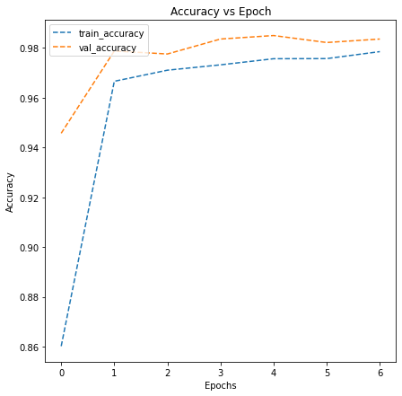

```python
# plotting the accuracies
plot_accuracy(history7)
```

```python
# Evaluating the model on test data
accuracy7 = model7.evaluate(test_images, test_labels, verbose=1)
print('\n', 'Test_Accuracy:-', accuracy7[1])
```

```
 Test_Accuracy:- 0.983846127986908
```

```
              precision    recall  f1-score   support

           0       0.98      0.98      0.98      1300
           1       0.98      0.98      0.98      1300

    accuracy                           0.98      2600
   macro avg       0.98      0.98      0.98      2600
weighted avg       0.98      0.98      0.98      2600
```

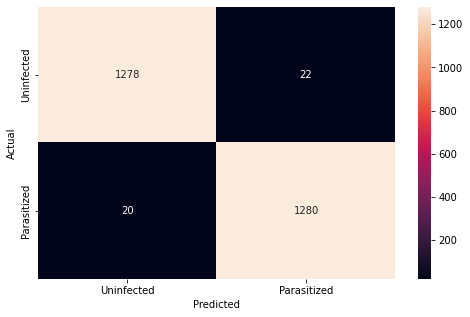

```python
# Plot the confusion matrix and generate a classification report for the model

pred = model7.predict(test_images)
pred = np.argmax(pred,axis = 1)
y_true = np.argmax(test_labels ,axis = 1)
#Printing the classification report
print(classification_report(y_true, pred))

#Plotting the heatmap using confusion matrix
cm = confusion_matrix(y_true, pred)
plt.figure(figsize=(8,5))
sns.heatmap(cm, annot=True,  fmt='.0f', xticklabels=['Uninfected', 'Parasitized'], yticklabels=['Uninfected', 'Parasitized'])
plt.ylabel('Actual')
plt.xlabel('Predicted')
plt.show()
```

```python
# Clearing the backed and setting the random seed

reset_random_seeds
```

```
<function __main__.reset_random_seeds>
```

New Model trying slightly higher model complexity

```python
#creating sequential model
model8 = Sequential()
model8.add(Conv2D(filters = 32, kernel_size = (3, 3), padding = "same", input_shape = (64, 64, 3)))
model8.add(Activation('relu'))
model8.add(MaxPool2D(pool_size=(2,2)))
model8.add(Conv2D(64, (3,3)))
model8.add(Activation('relu'))
model8.add(MaxPool2D(pool_size=(2,2)))
model8.add(Conv2D(64, (3,3)))
model8.add(Activation('relu'))
model8.add(MaxPool2D(pool_size=(2,2)))
model8.add(Flatten())
model8.add(Dense(128, activation='relu'))
model8.add(Dropout(0.5))
model8.add(Dense(2, activation='softmax'))
model8.summary()
```

```
Model: "sequential_18"
_________________________________________________________________
 Layer (type)                Output Shape              Param #
=================================================================
 conv2d_54 (Conv2D)          (None, 64, 64, 32)        896

 activation_36 (Activation)  (None, 64, 64, 32)        0

 max_pooling2d_54 (MaxPoolin  (None, 32, 32, 32)       0
 g2D)

 conv2d_55 (Conv2D)          (None, 30, 30, 64)        18496

 activation_37 (Activation)  (None, 30, 30, 64)        0

 max_pooling2d_55 (MaxPoolin  (None, 15, 15, 64)       0
 g2D)

 conv2d_56 (Conv2D)          (None, 13, 13, 64)        36928

 activation_38 (Activation)  (None, 13, 13, 64)        0

 max_pooling2d_56 (MaxPoolin  (None, 6, 6, 64)         0
 g2D)

 flatten_19 (Flatten)        (None, 2304)              0

 dense_40 (Dense)            (None, 128)               295040

 dropout_37 (Dropout)        (None, 128)               0

 dense_41 (Dense)            (None, 2)                 258

=================================================================
Total params: 351,618
Trainable params: 351,618
Non-trainable params: 0
_________________________________________________________________
```

```python
# Compiling the model

model8.compile(loss='categorical_crossentropy', optimizer='adam', metrics=['accuracy'])
```

```python
# Adding Callbacks to the model

callbacks = [EarlyStopping(monitor='val_loss', patience=2),
             ModelCheckpoint('.mdl_wts.hdf5', monitor='val_loss', save_best_only=True)]
```

```python
#Training the model

history8=model8.fit(train_images,train_labels,batch_size=32, callbacks = callbacks, validation_split=0.2,epochs=30,verbose=1)
```

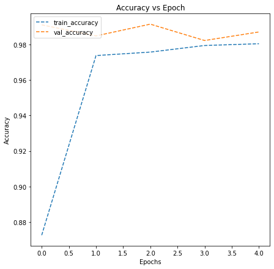

```python
# plotting the accuracies
plot_accuracy(history8)
```

```python
# Evaluating the model on test data
accuracy8 = model8.evaluate(test_images, test_labels, verbose=1)
print('\n', 'Test_Accuracy:-', accuracy8[1])
```

```
 Test_Accuracy:- 0.9846153855323792
```

```
              precision    recall  f1-score   support

           0       0.99      0.98      0.98      1300
           1       0.98      0.99      0.98      1300

    accuracy                           0.98      2600
   macro avg       0.98      0.98      0.98      2600
weighted avg       0.98      0.98      0.98      2600
```

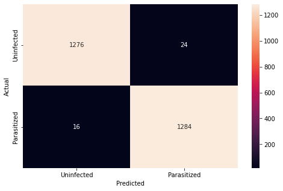

```python
# Plot the confusion matrix and generate a classification report for the model

pred = model8.predict(test_images)
pred = np.argmax(pred,axis = 1)
y_true = np.argmax(test_labels ,axis = 1)
#Printing the classification report
print(classification_report(y_true, pred))

#Plotting the heatmap using confusion matrix
cm = confusion_matrix(y_true, pred)
plt.figure(figsize=(8,5))
sns.heatmap(cm, annot=True,  fmt='.0f', xticklabels=['Uninfected', 'Parasitized'], yticklabels=['Uninfected', 'Parasitized'])
plt.ylabel('Actual')
plt.xlabel('Predicted')
plt.show()
```

Trying to construct a model with Batch Normalization

```python
# Clearing the backed and setting the random seed

reset_random_seeds
```

```
<function __main__.reset_random_seeds>
```

```python
model9 = Sequential()
model9.add(Conv2D(filters = 32, kernel_size = (3, 3), padding = "same", input_shape = (64, 64, 3)))
model9.add(BatchNormalization())
model9.add(Activation('relu'))
model9.add(MaxPool2D(pool_size=(2,2)))
model9.add(Conv2D(64, (3,3)))
model9.add(BatchNormalization())
model9.add(Activation('relu'))
model9.add(MaxPool2D(pool_size=(2,2)))
model9.add(Conv2D(64, (3,3)))
model9.add(BatchNormalization())
model9.add(Activation('relu'))
model9.add(MaxPool2D(pool_size=(2,2)))
model9.add(Flatten())
model9.add(Dense(64, activation='relu'))
model9.add(Dropout(0.5))
model9.add(Dense(2, activation='softmax'))
model9.summary()
```

```
Model: "sequential_19"
_________________________________________________________________
 Layer (type)                Output Shape              Param #
=================================================================
 conv2d_57 (Conv2D)          (None, 64, 64, 32)        896

 batch_normalization_9 (Batc  (None, 64, 64, 32)       128
 hNormalization)

 activation_39 (Activation)  (None, 64, 64, 32)        0

 max_pooling2d_57 (MaxPoolin  (None, 32, 32, 32)       0
 g2D)

 conv2d_58 (Conv2D)          (None, 30, 30, 64)        18496

 batch_normalization_10 (Bat  (None, 30, 30, 64)       256
 chNormalization)

 activation_40 (Activation)  (None, 30, 30, 64)        0

 max_pooling2d_58 (MaxPoolin  (None, 15, 15, 64)       0
 g2D)

 conv2d_59 (Conv2D)          (None, 13, 13, 64)        36928

 batch_normalization_11 (Bat  (None, 13, 13, 64)       256
 chNormalization)

 activation_41 (Activation)  (None, 13, 13, 64)        0

 max_pooling2d_59 (MaxPoolin  (None, 6, 6, 64)         0
 g2D)

 flatten_20 (Flatten)        (None, 2304)              0

 dense_42 (Dense)            (None, 64)                147520

 dropout_38 (Dropout)        (None, 64)                0

 dense_43 (Dense)            (None, 2)                 130

=================================================================
Total params: 204,610
Trainable params: 204,290
Non-trainable params: 320
_________________________________________________________________
```

```python
# Compiling the model

model9.compile(loss='categorical_crossentropy', optimizer='adam', metrics=['accuracy'])
```

```python
# Adding Callbacks to the model

callbacks = [EarlyStopping(monitor='val_loss', patience=2),
             ModelCheckpoint('.mdl_wts.hdf5', monitor='val_loss', save_best_only=True)]
```

```python
#Training the model

history9=model9.fit(train_images,train_labels,batch_size=32, callbacks = callbacks, validation_split=0.2,epochs=30,verbose=1)
```

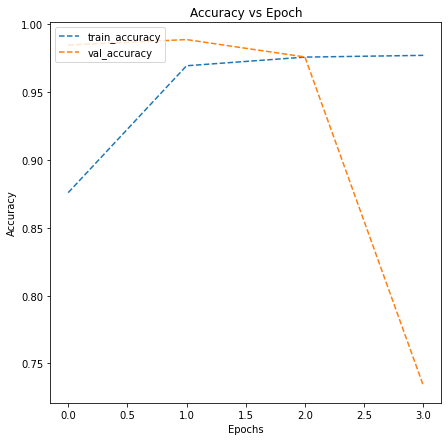

```python
# plotting the accuracies
plot_accuracy(history9)
```

```python
# Evaluating the model on test data
accuracy9 = model9.evaluate(test_images, test_labels, verbose=1)
print('\n', 'Test_Accuracy:-', accuracy9[1])
```

```
 Test_Accuracy:- 0.8899999856948853
```

```
              precision    recall  f1-score   support

           0       1.00      0.78      0.88      1300
           1       0.82      1.00      0.90      1300

    accuracy                           0.89      2600
   macro avg       0.91      0.89      0.89      2600
weighted avg       0.91      0.89      0.89      2600
```

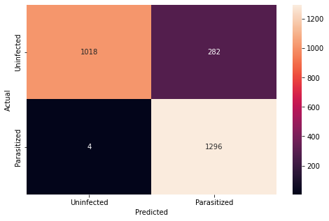

```python
# Plot the confusion matrix and generate a classification report for the model

pred = model9.predict(test_images)
pred = np.argmax(pred,axis = 1)
y_true = np.argmax(test_labels ,axis = 1)
#Printing the classification report
print(classification_report(y_true, pred))

#Plotting the heatmap using confusion matrix
cm = confusion_matrix(y_true, pred)
plt.figure(figsize=(8,5))
sns.heatmap(cm, annot=True,  fmt='.0f', xticklabels=['Uninfected', 'Parasitized'], yticklabels=['Uninfected', 'Parasitized'])
plt.ylabel('Actual')
plt.xlabel('Predicted')
plt.show()
```

```python
#creating sequential model
modelFinal = Sequential()
modelFinal.add(Conv2D(filters = 32, kernel_size = (3, 3), padding = "same", input_shape = (64, 64, 3)))
modelFinal.add(Activation('relu'))
modelFinal.add(MaxPool2D(pool_size=(2,2)))
modelFinal.add(Conv2D(64, (3,3)))
modelFinal.add(Activation('relu'))
modelFinal.add(MaxPool2D(pool_size=(2,2)))
modelFinal.add(Conv2D(64, (3,3)))
modelFinal.add(Activation('relu'))
modelFinal.add(MaxPool2D(pool_size=(2,2)))
modelFinal.add(Flatten())
modelFinal.add(Dense(64, activation='relu'))
modelFinal.add(Dropout(0.5))
modelFinal.add(Dense(2, activation='softmax'))
modelFinal.summary()
```

```
Model: "sequential_20"
_________________________________________________________________
 Layer (type)                Output Shape              Param #
=================================================================
 conv2d_60 (Conv2D)          (None, 64, 64, 32)        896

 activation_42 (Activation)  (None, 64, 64, 32)        0

 max_pooling2d_60 (MaxPoolin  (None, 32, 32, 32)       0
 g2D)

 conv2d_61 (Conv2D)          (None, 30, 30, 64)        18496

 activation_43 (Activation)  (None, 30, 30, 64)        0

 max_pooling2d_61 (MaxPoolin  (None, 15, 15, 64)       0
 g2D)

 conv2d_62 (Conv2D)          (None, 13, 13, 64)        36928

 activation_44 (Activation)  (None, 13, 13, 64)        0

 max_pooling2d_62 (MaxPoolin  (None, 6, 6, 64)         0
 g2D)

 flatten_21 (Flatten)        (None, 2304)              0

 dense_44 (Dense)            (None, 64)                147520

 dropout_39 (Dropout)        (None, 64)                0

 dense_45 (Dense)            (None, 2)                 130

=================================================================
Total params: 203,970
Trainable params: 203,970
Non-trainable params: 0
_________________________________________________________________
```

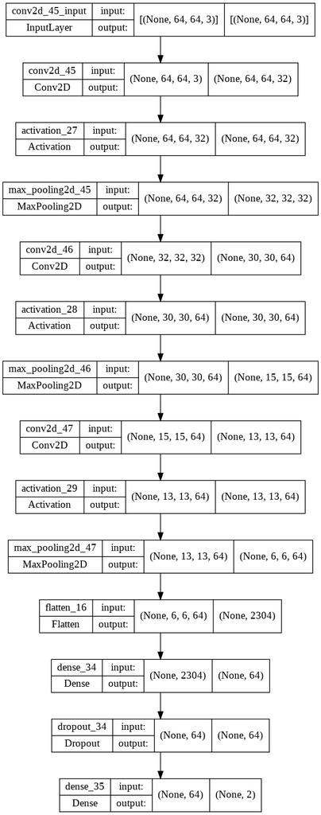

```python
## Visualizing the model

plot_model(model5, to_file='model_plotFinal.png', show_shapes=True, show_layer_names=True)
```

Observations and Conclusions drawn from the final model: Our Final model (Model5) had 98.8% overall accuaracy and only 10 cases of failing to identify parasitized samples. A simplified model with fewer layers, and fewer trainable paramaters performed better than our baseline model, and performed far better than the more complicated VGG model

Now we will run the Final Model with the HSV, Gaussian Blurred, and larger image size sets to see what gives us the best performance. This could be important for actual use in the field by physicians

```python
# Clearing the backed and setting the random seed

reset_random_seeds
```

```
<function __main__.reset_random_seeds>
```

```python
# Compiling the model

modelFinal.compile(loss='categorical_crossentropy', optimizer='adam', metrics=['accuracy'])
```

```python
#Training the model with HSV images

historyFinal=modelFinal.fit(gbx,train_labels,batch_size=32, callbacks = callbacks, validation_split=0.2,epochs=30,verbose=1)
```

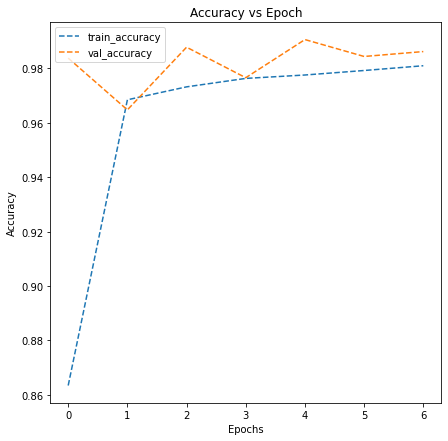

```python
# plotting the accuracies
plot_accuracy(historyFinal)
```

```python
# Evaluating the model on test data
accuracyFinalgbx = modelFinal.evaluate(gbxtest, test_labels, verbose=1)
print('\n', 'Test_Accuracy:-', accuracyFinalgbx[1])
```

```
 Test_Accuracy:- 0.98807692527771
```

```
              precision    recall  f1-score   support

           0       0.99      0.99      0.99      1300
           1       0.99      0.99      0.99      1300

    accuracy                           0.99      2600
   macro avg       0.99      0.99      0.99      2600
weighted avg       0.99      0.99      0.99      2600
```

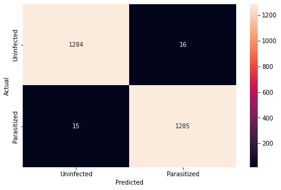

```python
# Plot the confusion matrix and generate a classification report for the model

pred = modelFinal.predict(gbxtest)
pred = np.argmax(pred,axis = 1)
y_true = np.argmax(test_labels ,axis = 1)
#Printing the classification report
print(classification_report(y_true, pred))

#Plotting the heatmap using confusion matrix
cm = confusion_matrix(y_true, pred)
plt.figure(figsize=(8,5))
sns.heatmap(cm, annot=True,  fmt='.0f', xticklabels=['Uninfected', 'Parasitized'], yticklabels=['Uninfected', 'Parasitized'])
plt.ylabel('Actual')
plt.xlabel('Predicted')
plt.show()
```

```python
# Clearing the backed and setting the random seed

reset_random_seeds
```

```
<function __main__.reset_random_seeds>
```

```python
# Compiling the model

modelFinal.compile(loss='categorical_crossentropy', optimizer='adam', metrics=['accuracy'])
```

```python
#Training the model with Gaussian Blurred Images

historyFinal=modelFinal.fit(gfx,train_labels,batch_size=32, callbacks = callbacks, validation_split=0.2,epochs=30,verbose=1)
```

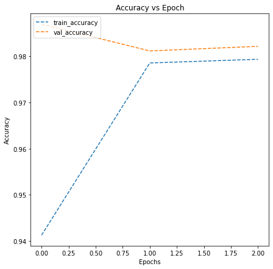

```python
# plotting the accuracies
plot_accuracy(historyFinal)
```

```python
# Evaluating the model on test data
accuracyFinalgfx = modelFinal.evaluate(gfxtest, test_labels, verbose=1)
print('\n', 'Test_Accuracy:-', accuracyFinalgbx[1])
```

[output not shown]

```
              precision    recall  f1-score   support

           0       0.99      0.98      0.98      1300
           1       0.98      0.99      0.98      1300

    accuracy                           0.98      2600
   macro avg       0.98      0.98      0.98      2600
weighted avg       0.98      0.98      0.98      2600
```

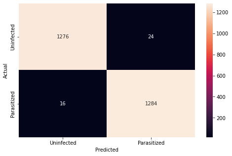

```python
# Plot the confusion matrix and generate a classification report for the model

pred = modelFinal.predict(gfxtest)
pred = np.argmax(pred,axis = 1)
y_true = np.argmax(test_labels ,axis = 1)
#Printing the classification report
print(classification_report(y_true, pred))

#Plotting the heatmap using confusion matrix
cm = confusion_matrix(y_true, pred)
plt.figure(figsize=(8,5))
sns.heatmap(cm, annot=True,  fmt='.0f', xticklabels=['Uninfected', 'Parasitized'], yticklabels=['Uninfected', 'Parasitized'])
plt.ylabel('Actual')
plt.xlabel('Predicted')
plt.show()
```

```python
# Clearing the backed and setting the random seed

reset_random_seeds
```

```
<function __main__.reset_random_seeds>
```

```python
# Building the same final model for larger image sizes

#creating sequential model
modelFinallg = Sequential()
modelFinallg.add(Conv2D(filters = 32, kernel_size = (3, 3), padding = "same", input_shape = (100, 100, 3)))
modelFinallg.add(Activation('relu'))
modelFinallg.add(MaxPool2D(pool_size=(2,2)))
modelFinallg.add(Conv2D(64, (3,3)))
modelFinallg.add(Activation('relu'))
modelFinallg.add(MaxPool2D(pool_size=(2,2)))
modelFinallg.add(Conv2D(64, (3,3)))
modelFinallg.add(Activation('relu'))
modelFinallg.add(MaxPool2D(pool_size=(2,2)))
modelFinallg.add(Flatten())
modelFinallg.add(Dense(64, activation='relu'))
modelFinallg.add(Dropout(0.5))
modelFinallg.add(Dense(2, activation='softmax'))
modelFinallg.summary()
```

```
Model: "sequential_22"
_________________________________________________________________
 Layer (type)                Output Shape              Param #
=================================================================
 conv2d_66 (Conv2D)          (None, 100, 100, 32)      896

 activation_48 (Activation)  (None, 100, 100, 32)      0

 max_pooling2d_66 (MaxPoolin  (None, 50, 50, 32)       0
 g2D)

 conv2d_67 (Conv2D)          (None, 48, 48, 64)        18496

 activation_49 (Activation)  (None, 48, 48, 64)        0

 max_pooling2d_67 (MaxPoolin  (None, 24, 24, 64)       0
 g2D)

 conv2d_68 (Conv2D)          (None, 22, 22, 64)        36928

 activation_50 (Activation)  (None, 22, 22, 64)        0

 max_pooling2d_68 (MaxPoolin  (None, 11, 11, 64)       0
 g2D)

 flatten_23 (Flatten)        (None, 7744)              0

 dense_48 (Dense)            (None, 64)                495680

 dropout_41 (Dropout)        (None, 64)                0

 dense_49 (Dense)            (None, 2)                 130

=================================================================
Total params: 552,130
Trainable params: 552,130
Non-trainable params: 0
_________________________________________________________________
```

```python
# Compiling the model

modelFinallg.compile(loss='categorical_crossentropy', optimizer='adam', metrics=['accuracy'])
```

```python
#Training the model with Larger image size

historyFinallg=modelFinallg.fit(train_imageslg,train_labels,batch_size=32, callbacks = callbacks, validation_split=0.2,epochs=30,verbose=1)
```

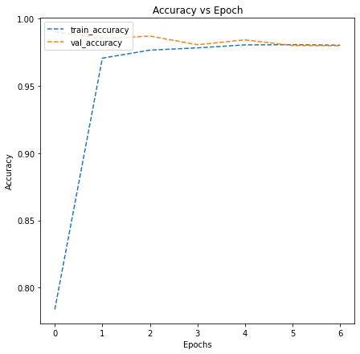

```python
# plotting the accuracies
plot_accuracy(historyFinallg)
```

```python
# Evaluating the model on test data
accuracyFinallg = modelFinallg.evaluate(test_imageslg, test_labels, verbose=1)
print('\n', 'Test_Accuracy:-', accuracyFinalgbx[1])
```

[output not shown]

```
              precision    recall  f1-score   support

           0       0.99      0.98      0.99      1300
           1       0.98      0.99      0.99      1300

    accuracy                           0.99      2600
   macro avg       0.99      0.99      0.99      2600
weighted avg       0.99      0.99      0.99      2600
```

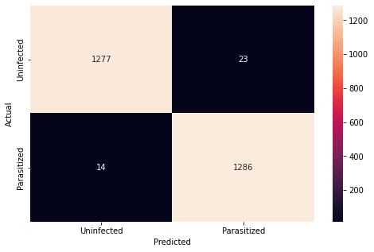

```python
# Plot the confusion matrix and generate a classification report for the model

pred = modelFinallg.predict(test_imageslg)
pred = np.argmax(pred,axis = 1)
y_true = np.argmax(test_labels ,axis = 1)
#Printing the classification report
print(classification_report(y_true, pred))

#Plotting the heatmap using confusion matrix
cm = confusion_matrix(y_true, pred)
plt.figure(figsize=(8,5))
sns.heatmap(cm, annot=True,  fmt='.0f', xticklabels=['Uninfected', 'Parasitized'], yticklabels=['Uninfected', 'Parasitized'])
plt.ylabel('Actual')
plt.xlabel('Predicted')
plt.show()
```

Our Final Model performed very well with smaller (64x64), larger (100x100), HSV images, and Gaussian Blurred images.

The Final model performed best with the 64x64 image size considering it had among the highest overall model performance with that image size (98.8%), the fewest missed parasitized samples (10), and the fastest overall model training time (Under 20 seconds). The fast computing time could be an important consideration in the field where fast internet connections and access to robust servers might not be easily to come by.

```python
%%shell
jupyter nbconvert --to html /content/James_Hochleutner_Final_Deep_Learning.ipynb
```

```
[NbConvertApp] Converting notebook /content/James_Hochleutner_Final_Deep_Learning.ipynb to html
[NbConvertApp] Writing 2645163 bytes to /content/James_Hochleutner_Final_Deep_Learning.html
```